# CorSer

### Non Radio DataFrames

Extra data frames are also available to acces to non radio information. In particular, it exists :

- *S.devdf*: the device dataframe, which gives mechanical information: position (x,y,z), velocity (v,vx,vy,vz) and acceleration (a,ax,ay,az) of the devices at any time stamps
- *S.distdf*: the distance data frame, which gives ground truth distances between the different radio links.

Here is the 5 last data of the device data frame...

```python
S.devdf.tail(5)
```

|  | id | subject | x | y | z | v | vx | vy | vz | a | ax | ay | az |
| --- | --- | --- | --- | --- | --- | --- | --- | --- | --- | --- | --- | --- | --- |
| 104.2 | HKB:14 | Nicolas | 0.158588 | -1.574102 | 0.526740 | 0.012375 | -0.005046 | 0.010521 | 0.004119 | 2.241849 | 1.972888 | 0.738384 | 0.767065 |
| 104.2 | HKB:1 |  | 0.018552 | -2.749937 | 0.979166 | 0.000000 | 0.000000 | 0.000000 | 0.000000 | 0.000000 | 0.000000 | 0.000000 | 0.000000 |
| 104.2 | HKB:16 | Nicolas | -0.229677 | -1.445404 | 0.175125 | 0.010563 | -0.007414 | -0.006640 | -0.003540 | 0.547761 | 0.122199 | -0.250196 | -0.471711 |
| 104.2 | HKB:10 | Nicolas | 0.262695 | -1.433168 | 1.143153 | 0.057829 | -0.048329 | -0.030039 | -0.010302 | 0.924303 | -0.697193 | 0.368582 | -0.482085 |
| 104.2 | HKB:3 |  | 0.021135 | 3.375590 | 1.003871 | 0.000000 | 0.000000 | 0.000000 | 0.000000 | 0.000000 | 0.000000 | 0.000000 | 0.000000 |

... and the 5 last data of the distance data frame:

```python
S.distdf.tail(5)
```

|  | HKB:1-HKB:2 | HKB:1-HKB:3 | HKB:1-HKB:4 | HKB:1-HKB:5 | HKB:1-HKB:6 | HKB:1-HKB:7 | HKB:1-HKB:8 | HKB:1-HKB:9 | HKB:1-HKB:10 | HKB:1-HKB:11 | ... | HKB:12-HKB:15 | HKB:12-HKB:16 | HKB:13-HKB:14 | HKB:13-HKB:15 | HKB:13-HKB:16 | HKB:14-HKB:15 | HKB:14-HKB:16 | HKB:15-HKB:16 | BS:0-BS:74 | BS:0-BS:157 |
| --- | --- | --- | --- | --- | --- | --- | --- | --- | --- | --- | --- | --- | --- | --- | --- | --- | --- | --- | --- | --- | --- |
| 104.159996 | 6.102589 | 6.125578 | 6.135849 | 1.308815 | 1.163639 | 1.131707 | 1.387571 | 1.322510 | 1.350930 | 1.223406 | ... | 1.071233 | 0.990922 | 0.411064 | 0.753501 | 0.910143 | 0.364396 | 0.539795 | 0.445009 | 1.046829 | 0.119864 |
| 104.169997 | 6.102589 | 6.125578 | 6.135849 | 1.309074 | 1.163713 | 1.131587 | 1.387549 | 1.322884 | 1.350486 | 1.223658 | ... | 1.071489 | 0.990873 | 0.410944 | 0.753502 | 0.909901 | 0.364396 | 0.539682 | 0.445027 | 1.046903 | 0.119868 |
| 104.179998 | 6.102589 | 6.125578 | 6.135849 | 1.309470 | 1.163938 | 1.131414 | 1.387530 | 1.323230 | 1.350018 | 1.223874 | ... | 1.071624 | 0.990832 | 0.410933 | 0.753522 | 0.909759 | 0.364316 | 0.539533 | 0.445038 | 1.046936 | 0.119734 |
| 104.189999 | 6.102589 | 6.125578 | 6.135849 | 1.309873 | 1.164064 | 1.131319 | 1.387509 | 1.323601 | 1.349608 | 1.224129 | ... | 1.071955 | 0.990734 | 0.410871 | 0.753529 | 0.909520 | 0.364281 | 0.539368 | 0.445063 | 1.047000 | 0.119982 |
| 104.200000 | 6.102589 | 6.125578 | 6.135849 | 1.310357 | 1.164289 | 1.131228 | 1.387509 | 1.323915 | 1.349214 | 1.224341 | ... | 1.072294 | 0.990736 | 0.410651 | 0.753482 | 0.909291 | 0.364271 | 0.539394 | 0.445110 | 1.046967 | 0.119830 |

5 rows × 122 columns

### Involved devices (*S.dev*)

The *S.dev* command allows to obtain the complete list of devices involved in the serie and:

- the Name of the device used in the radio dataframe
- the Real device Id used during the measurement campaign
- The corresponding device Id used on the Body wear description
- At wich Subject the device is related.

Infrastrucure access point obviously don't have related Subject.

```python
S.dev
```

```
Name in Dataframe     | Real Id | Body Id  | Subject
========================================================
AP4                   |       4 | HKB:4    |
AP1                   |       1 | HKB:1    |
AP2                   |       2 | HKB:2    |
AP3                   |       3 | HKB:3    |
--------------------------------------------------------
AnkleRight            |      16 | HKB:16   | Nicolas
KneeLeft              |      14 | HKB:14   | Nicolas
AnkleLeft             |      15 | HKB:15   | Nicolas
WristRight            |      12 | HKB:12   | Nicolas
WristLeft             |      13 | HKB:13   | Nicolas
ElbowLeft             |      10 | HKB:10   | Nicolas
HipRight              |      11 | HKB:11   | Nicolas
HeadRight             |       5 | HKB:5    | Nicolas
TorsoTopRight         |       6 | HKB:6    | Nicolas
TorsoTopLeft          |       7 | HKB:7    | Nicolas
BackCenter            |       8 | HKB:8    | Nicolas
ElbowRight            |       9 | HKB:9    | Nicolas
                      |         |          |
WristRight            |     157 | BS:157   | Nicolas
AnkleRight            |      74 | BS:74    | Nicolas
HandRight             |       0 | BS:0     | Nicolas
--------------------------------------------------------
```

## Accessing the data

In order to help people not familiar with the Pandas query format, some useful methods are provided in order to extract values from radio and non radio dataframes.

### Get device position (*S.getdevp*)

The value of the device position at a specific time or range or time can be obtained by specifying:

- The device (Name in dataframe OR real id OR body id)
- The radio *techno* (Precising the techno is optional except when an ambiguity occurs, therefore error is raised)
- a given time in second or a [start time,stop time]. If no time is given, the position for all time stamps are provided

Hence, It is possible to get the positions of the HKB radio node 11 (Hip Right), between 5.0 seconds and 5.2 seconds with:

```python
Positions = S.getdevp(11,t=[5,5.2])
Positions
```

|  | x | y | z |
| --- | --- | --- | --- |
| 5.000480 | -0.139566 | 0.224905 | 1.016796 |
| 5.010481 | -0.139553 | 0.224845 | 1.016826 |
| 5.020482 | -0.139545 | 0.224825 | 1.016818 |
| 5.030483 | -0.139564 | 0.224730 | 1.016849 |
| 5.040484 | -0.139609 | 0.224642 | 1.016859 |
| 5.050485 | -0.139580 | 0.224613 | 1.016898 |
| 5.060486 | -0.139554 | 0.224586 | 1.016920 |
| 5.070487 | -0.139604 | 0.224492 | 1.016937 |
| 5.080488 | -0.139545 | 0.224452 | 1.016989 |
| 5.090489 | -0.139521 | 0.224391 | 1.016992 |
| 5.100489 | -0.139386 | 0.224397 | 1.016997 |
| 5.110490 | -0.139296 | 0.224315 | 1.017041 |
| 5.120491 | -0.139164 | 0.224189 | 1.017098 |
| 5.130492 | -0.138988 | 0.224128 | 1.017131 |
| 5.140493 | -0.138810 | 0.224048 | 1.017142 |
| 5.150494 | -0.138605 | 0.223969 | 1.017148 |
| 5.160495 | -0.138406 | 0.223877 | 1.017164 |
| 5.170496 | -0.138043 | 0.223803 | 1.017230 |
| 5.180497 | -0.137791 | 0.223654 | 1.017305 |
| 5.190498 | -0.137388 | 0.223580 | 1.017321 |

**NOTE : You may also obtain a classical numpy array instead of this Pandas object by using the "*values*" method :**

```python
Positions.values
```

```
array([[-0.13956557,  0.22490462,  1.01679608],
       [-0.13955284,  0.22484492,  1.01682581],
       [-0.13954524,  0.22482529,  1.01681787],
       [-0.1395645 ,  0.2247298 ,  1.01684918],
       [-0.13960907,  0.224642  ,  1.01685901],
       [-0.13957962,  0.2246127 ,  1.01689801],
       [-0.13955351,  0.22458575,  1.01691986],
       [-0.13960399,  0.22449205,  1.01693719],
       [-0.13954485,  0.22445244,  1.01698865],
       [-0.13952087,  0.22439058,  1.0169917 ],
       [-0.13938625,  0.22439655,  1.0169975 ],
       [-0.13929645,  0.22431535,  1.01704102],
       [-0.13916449,  0.22418907,  1.0170979 ],
       [-0.1389884 ,  0.22412761,  1.01713135],
       [-0.13880983,  0.22404759,  1.0171424 ],
       [-0.13860497,  0.22396939,  1.01714777],
       [-0.1384055 ,  0.22387668,  1.01716443],
       [-0.13804305,  0.22380293,  1.01722955],
       [-0.13779123,  0.2236543 ,  1.01730511],
       [-0.13738791,  0.22358025,  1.01732141]])
```

### Get link value (*S.getlink*)

The value of a link *a* and *b* at a specific time or range or time can be obtained by specifying:

- The device $a$ (Name in dataframe OR real id OR body id)
- The device $b$ (Name in dataframe OR real id OR body id)
- The radio *technoa* and *technob* (Precising the techno is optional except when an ambiguity occurs, therefore error is raised)
- a given time in second or a [start time,stop time]. If no time is given, the position for all time stamps are provided

Hence, It is possible to get the HKB values between radio node 11 (Hip Right) and node 16 (Ankle Right) , between 5 seconds and 5.2 seconds with:

```python
Values = S.getlink(11,16,t=[5,5.2])
Values
```

```
5.000500   -67
5.010501   -66
5.020502   -66
5.030503   -66
5.040504   -67
5.050505   -67
5.060506   -67
5.070507   -67
5.080508   -67
5.090509   -67
5.100510   -67
5.110511   -67
5.120512   -67
5.130513   -67
5.140514   -70
5.150515   -70
5.160516   -70
5.170517   -78
5.180518   -78
5.190519   -75
Name: HipRight-AnkleRight, dtype: float64
```

### Get link distance (*S.getlinkd*)

The ground truth distance separating a device *a* and device *b* at a specific time or range or time can be obtained by specifying:

- The device $a$ (Name in dataframe OR real id OR body id)
- The device $b$ (Name in dataframe OR real id OR body id)
- The radio *technoa* and *technob* (Precising the techno is optional except when an ambiguity occurs, therefore error is raised)
- a given time in second or a [start time,stop time]. If no time is given, the position for all time stamps are provided

Hence, It is possible to get the HKB values between radio node 11 (Hip Right) and node 16 (Ankle Right) , between 5 seconds and 5.2 seconds with:

```python
Distances = S.getlinkd(11,16,t=[5,5.2])
Distances
```

```
5.000480    0.845013
5.010481    0.845034
5.020482    0.845045
5.030483    0.845068
5.040484    0.845090
5.050485    0.845180
5.060486    0.845229
5.070487    0.845235
5.080488    0.845309
5.090489    0.845339
5.100489    0.845353
5.110490    0.845423
5.120491    0.845482
5.130492    0.845559
5.140493    0.845563
5.150494    0.845595
5.160495    0.845602
5.170496    0.845677
5.180497    0.845769
5.190498    0.845785
Name: HKB:11-HKB:16, dtype: float64
```

## Visualizing the Data

### Native Pandas Vizualization

Because radio data in CorSer are stored into Pandas objects, convenient vizualization method are directly available. Most of them can be found here : http://pandas.pydata.org/pandas-docs/stable/visualization.html

As an example, it is possbile tthe previous obtained values and distance with :

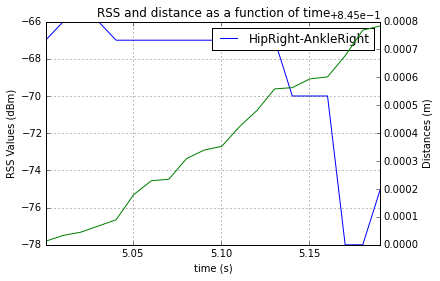

```python
# Ploting
ax=Values.plot() # plot values
l=Distances.plot(secondary_y=True,ax=ax) # plot distances on the right side

## Labelling
ax.legend() # add legend box
ax.set_ylabel('RSS Values (dBm)') # set left ylabel
ax.right_ax.set_ylabel('Distances (m)') # set right ylabel
ax.set_xlabel('time (s)') # set xlabel
ax.set_title('RSS and distance as a function of time')
```

In addition, CorSer also provides specific plotting methods which includes extra features.

### Plot method (S.plot)

The plot function allows to display the radio values of a link. The main parameters are always the same:

- The device $a$ (Name in dataframe OR real id OR body id)
- The device $b$ (Name in dataframe OR real id OR body id)
- The radio *techno* (Precising the techno is optional except when an ambiguity occurs, therefore error is raised)
- A given time in second or a [start time,stop time]. If no time is given, the position for all time stamps are provided

More option are availble, please refer to the docstring (*S.plot?*) for more information

#### Plot values

Continuying with the same example, it is possible to plot the HKB values between radio node 11 (Hip Right) and node 16 (Ankle Right) , between 5 seconds and 5.2 seconds with:

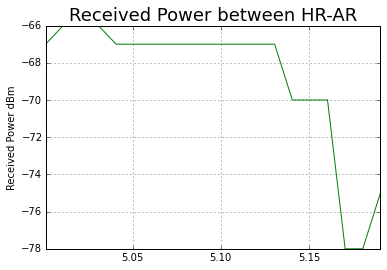

```python
S.plot(11,16,t=[5,5.2])
```

#### Plot distance

As well, it is possible to plot the distance using the *distance* parameter

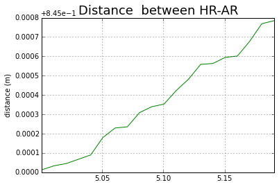

```python
S.plot(11,16,t=[5,5.2],distance = True)
```

It is also possible to get the same result than with the Pandas procedure with the following code :

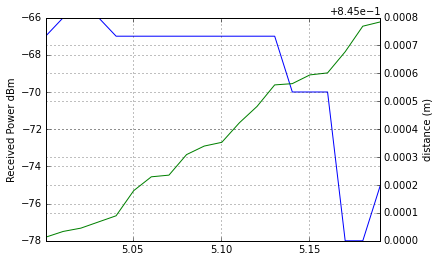

```python
# plot value
f,ax = S.plot(11,16,t=[5,5.2],color ='b',title=False)

# create right axis
ax2=ax.twinx()

# plot distance
S.plot(11,16,t=[5,5.2],color ='g',title=False,
       distance=True,
       fig=f,ax=ax2)
```

### Plot visibility method (S.pltvisi)

In order to go further in the radio value interpretation, it is convenient to have some extra information about the **optical visibility/occultation** of devices involved in a link.

This information allows to determine the line of sight (LOS) or non line of sight (NLOS) cases which are crutial for power level and delay interpretation.

This information can be superimposed to the radio values. To this end, the plot visibility (*S.pltvisi*) method is used. The **hatched** area denoted **NLOS** wheras **clear** area denotes **LOS**.

Parameters are the same than those the *plot* method:

[figure not shown]

```python
f,ax = S.plot(1,16)
S.pltvisi(1,16,fig=f,ax=ax)
```

### Plot mobility method (S.pltmob)

As well it is possible to determine and indcicate if the subject is static or not by using the plot mobility method (*S.pltmob*). The succession of Static and Mobile sequences are denoted $S_x$ and $M_x$ resplectively, where $x$ is an index of the sequence.

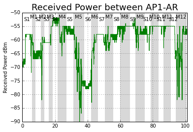

```python
f,ax = S.plot(1,16)
S.pltmob(fig=f,ax=ax)
```

The 2 upmentionned methods can also be used simultaneously as shown in the following example :

[figure not shown]

```python
# plot data in green)
f,ax=S.plthkb(1,13,figsize=(10,5))
# plot optical occultation (hatched lines)
S.pltvisi(1,13,fig=f,ax=ax)
# plot subject mobility (grey areas)
S.pltmob(showvel=False,ylim=([-100,-40]),fig=f,ax=ax)
```

### 3D plot (S._show3)

With the help of the Mayavi Library, the CorSer class allows to display in 3D :

- The building where measurements have taken place
- The positions of Vicon Cameras
- The Multi-cylindric representation of the the subjects involved in the selected serie
- The position/ antenna pattern of the devices on the body(ies) and in the infrastructure.

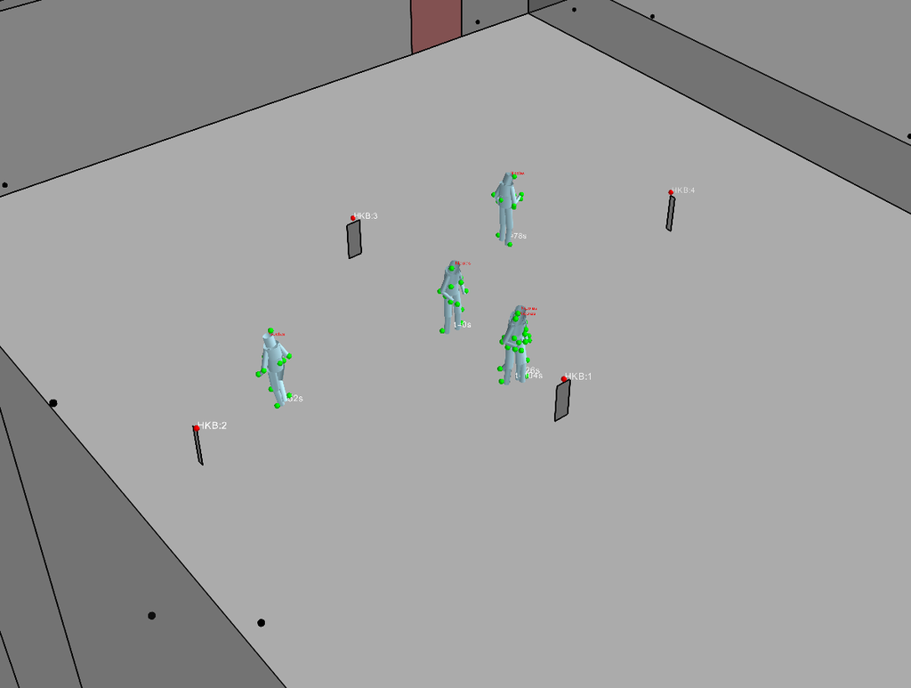

```python
S._show3()

# the following line is only used to display in the notebook a screenshot of the mayavi window
myu.inotshow('fig1')
```

#### Specify time (*bodytime* parameter)

In order to display scene at specific timestamps, the parameter *bodytime* can be used

Example: to show the body position at $t=0s$, $t=30s$ and $t=90s$.

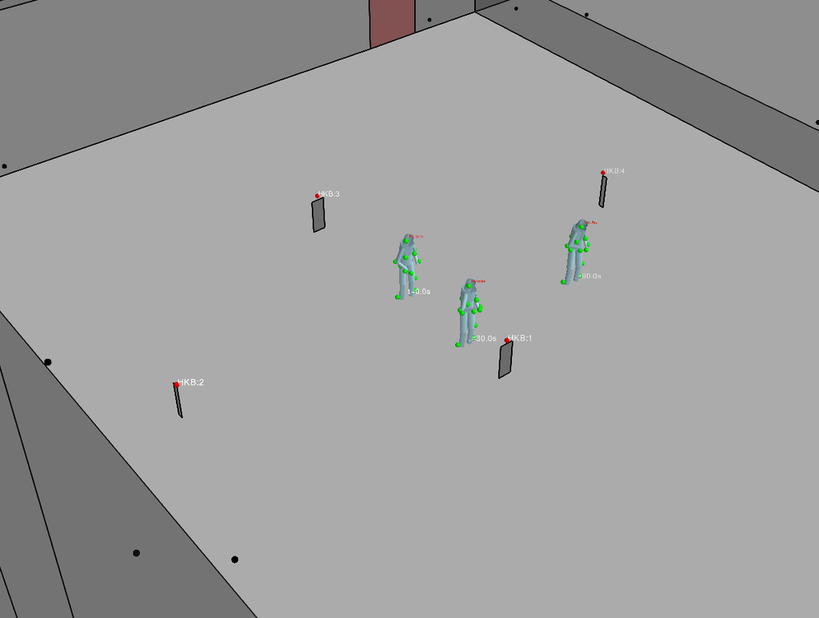

```python
S._show3(bodytime=[0.,30.,90.])

# the following line is only used to display in the notebook a screenshot of the mayavi window
myu.inotshow('fig2')
```

#### display trajectory (*trajectory* parameter)

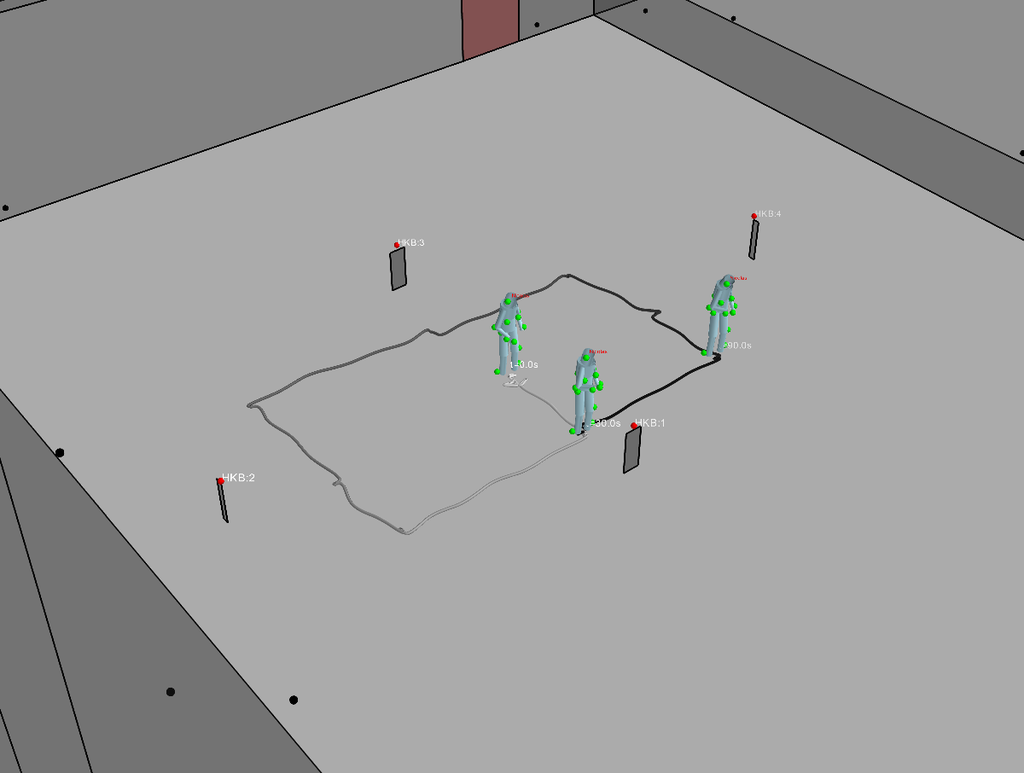

```python
S._show3(trajectory = True,bodytime=[0.,30.,90.])

# the following line is only used to display in the notebook a screenshot of the mayavi window
myu.inotshow('fig3')
```

### 3D plot interactive (*S._show3i*)

The method *S._show3i()* allows to display the 3D scene with an extra window incluying a slider acting like a jog shuttle, to choose the timestamp to vizualize.

Note : This function is note available in the notebook

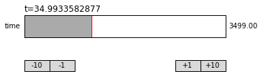

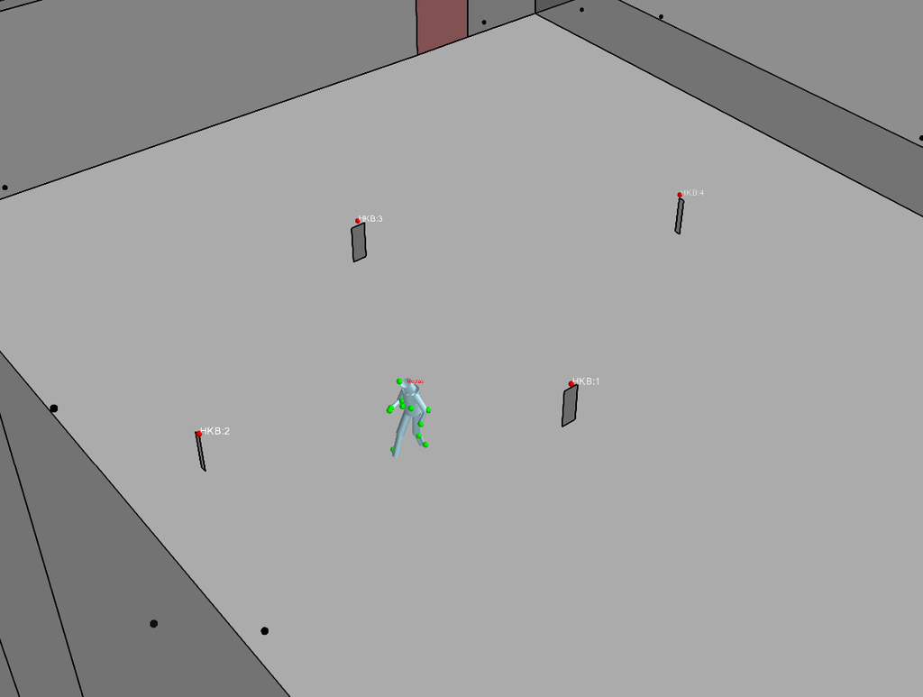

```python
S._show3i(t=35) # t=35 is an initialization value

# the following line is only used to display in the notebook a screenshot of the mayavi window
myu.inotshow('fig4')
```

### Interactive visibility (*S.imshowvisibility_i*)

The visibility matrix can be displayed simultaneously to the 3D view.

For that purpose a visibility/occultation matrix is computed the first time the vizualization is called. The following code displays the tisibility matrix and associated 3D scene at the inital time $t=35s$

```
Visibility is computed only once, Please wait

processing shadowing from
```

```
 Nicolas
```

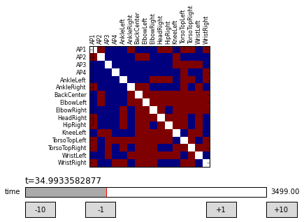

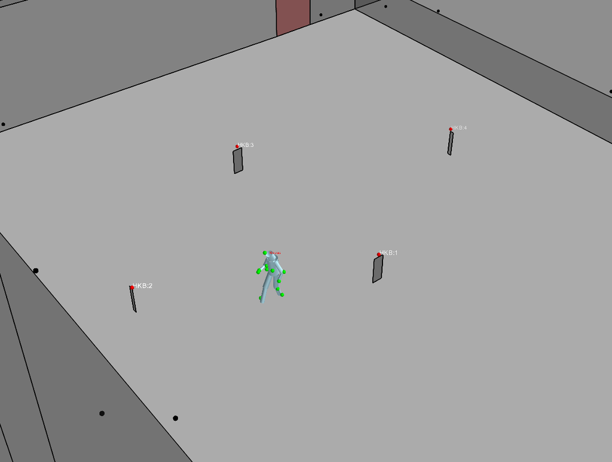

```python
S.imshowvisibility_i(t=35)

# the following line is only used to display in the notebook a screenshot of the mayavi window
myu.inotshow('fig5')
```

## Using Pylayers Ray-tracing with CorSer data

Coming soon ...

```python
import pylayers.simul.simultraj as st
```

```python
ST=st.Simul(S)
```

```python
from IPython.core.display import HTML
def css_styling():
    styles = open("../styles/custom.css", "r").read()
    return HTML(styles)
css_styling()
```